# Infering physical interactions using RNAMagnet

Lars Velten

2019-01-22

This vignette demonstrates the use of RNAMagnet for infering spatial co-localization in the context of data from the bone marrow niche. A second vignette describes the use of RNAMagnet for signaling analyses.

Let’s assume that our organ of interest has a number of **scaffold structures**. In the context of bone marrow, those would be arteriolar and sinusoidal blood vessels, as well as the ‘endosteal’ surface of the bone. These scaffolds can be defined by **anchor cell types**, i.e. cell types we know to define our scaffolds. In the context on bone marrow, those would be **sinusoidal endothelial cells (ECs)**, **arteriolar ECs**, and **osteoblasts**; **Smooth muscle cells**, which exclusively line arterioles, are a possible fourth anchor.

The idea behind of RNAMagnet is to identify, for each single cell from a dataset, which of these anchors it is most likely to bind to. Potential physical interactions between cells and anchors are scored based on the mutual expression level of receptors that bind to surface molecules expressed on a second cell (e.g. Selectin P ligand-Selectin P, or homophilic interactions of cadherins), or based on receptors binding to structural extracellular matrix components (e.g. Integrin a1b1-Collagen). We can retrieve the underlying receptor-ligand lists using `getLigandsReceptors`.

```r
require(RNAMagnet)
require(ggplot2)

ligrec <- getLigandsReceptors("1.0.0",cellularCompartment = c("ECM","Surface","Both"),manualAnnotation = "Correct")
head(ligrec)
```

```
##        Pair.Name Ligand.Mouse Receptor.Mouse     Source ManualAnnotation
## 26      Bgn-Tlr2          Bgn           Tlr2 Ramilowski          Correct
## 27      Bgn-Tlr4          Bgn           Tlr4 Ramilowski          Correct
## 114 Col11a1-Ddr1      Col11a1           Ddr1 Ramilowski          Correct
## 115 Col14a1-Cd44      Col14a1           Cd44 Ramilowski          Correct
## 116 Col18a1-Gpc1      Col18a1           Gpc1 Ramilowski          Correct
## 117 Col18a1-Gpc4      Col18a1           Gpc4 Ramilowski          Correct
##     Ligand.CC Ligand.GO          Reference
## 26        ECM     Other           24480070
## 27        ECM     Other           24480070
## 114       ECM     Other            9659900
## 115       ECM     Other            8986622
## 116       ECM     Other 11336704, 11336700
## 117       ECM     Other           11336704
```

## The data at hand

Let’s familiarize ourselves with the dataset at hand: Our dataset contains 7497 cells from 32 populations and is stored as an object of class **seurat**.

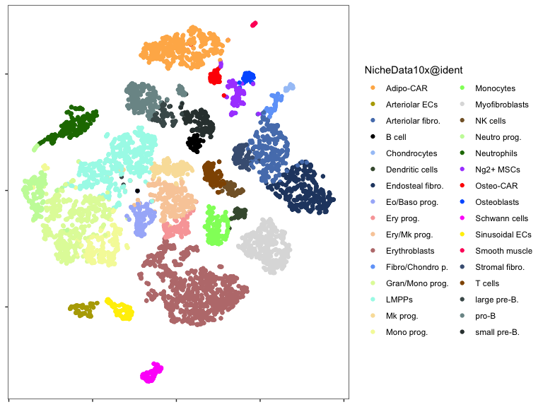

```r
qplot(x = NicheData10x@dr$tsne@cell.embeddings[,1], y = NicheData10x@dr$tsne@cell.embeddings[,2], color =NicheData10x@ident) + scale_color_manual(values = NicheDataColors) + theme_bw() + theme(panel.grid = element_blank(), axis.text = element_blank(), axis.title = element_blank())
```

## Running RNAMagnet for physical interactions

Simply run `RNAMagnetAnchors`:

```r
  result <- RNAMagnetAnchors(NicheData10x, anchors = c("Sinusoidal ECs","Arteriolar ECs","Smooth muscle","Osteoblasts"))
```

```
## Setting everything up...
## Now running MAGIC to impute dropout values...
## Now running RNAMagnet...
```

The result is a dataframe that contains

- The anchor population that a cell is most specifically interacting with (‘direction’)
- The overall strength of the interaction (‘adhesiveness’)
- Specificity scores for interaction with each of the anchor populations.

```r
head(result)
```

```
##                                   direction adhesiveness Sinusoidal.ECs
## 2018_2_HSPC_AAACCTGAGTGTCTCA  Smooth muscle     16.27392  -0.0242121920
## 2018_2_HSPC_AAACCTGCACAGAGGT    Osteoblasts     19.00299  -0.0127078249
## 2018_2_HSPC_AAACCTGGTACGAAAT    Osteoblasts     21.98338   0.0141468023
## 2018_2_HSPC_AAACCTGGTCCATGAT  Smooth muscle     16.66003  -0.0088117265
## 2018_2_HSPC_AAACCTGGTTCCACTC    Osteoblasts     20.43373   0.0001394666
## 2018_2_HSPC_AAACGGGAGACCACGA Sinusoidal ECs     20.80755   0.0165025003
##                              Arteriolar.ECs Smooth.muscle  Osteoblasts
## 2018_2_HSPC_AAACCTGAGTGTCTCA    0.003528526   0.030995952 -0.010312286
## 2018_2_HSPC_AAACCTGCACAGAGGT   -0.012149264  -0.003984468  0.028841557
## 2018_2_HSPC_AAACCTGGTACGAAAT    0.001807560  -0.033938082  0.017983720
## 2018_2_HSPC_AAACCTGGTCCATGAT   -0.001536692   0.025289806 -0.014941388
## 2018_2_HSPC_AAACCTGGTTCCACTC   -0.012290467  -0.008028908  0.020179909
## 2018_2_HSPC_AAACGGGAGACCACGA   -0.006114256  -0.013977688  0.003589444
```

The result can easily be highlighted on a t-SNE…

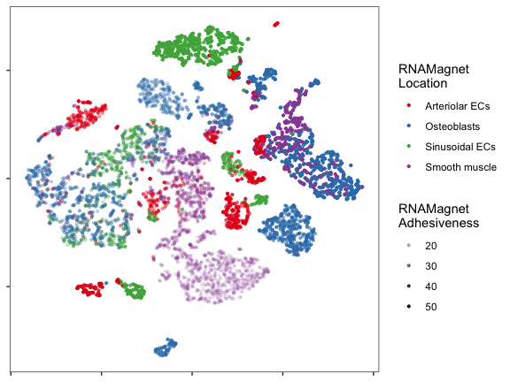

```r
qplot(x =NicheData10x@dr$tsne@cell.embeddings[,1], y=NicheData10x@dr$tsne@cell.embeddings[,2], color = direction,size=I(0.75),alpha= adhesiveness,data=result) + scale_color_brewer(name = "RNAMagnet\nLocation",palette= "Set1") + scale_alpha_continuous(name = "RNAMagnet\nAdhesiveness") + theme_bw() + theme(panel.grid = element_blank(), axis.text = element_blank(), axis.title = element_blank())
```

…or we can compute population-level summaries, maybe after subsetting for popualtions that have a certain level of adhesiveness:

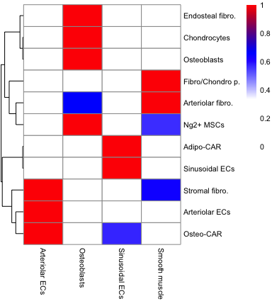

```r
require(plyr)
require(reshape2)
require(pheatmap)

result$id <- NicheData10x@ident

summarised <- ddply(result, c("id"), summarise,  RNAmagnet.score = table(direction) / length(direction), n = rep(length(direction),4), RNAmagnet.adhesiveness = rep(mean(adhesiveness),4), experiment = names(table(direction)))

castMagnet <- dcast(subset(summarised, RNAmagnet.adhesiveness > 35), id ~ experiment, value.var = "RNAmagnet.score")
rownames(castMagnet) <- castMagnet[,1]
castMagnet <- castMagnet[,-1]
castMagnet <- t(apply(castMagnet,1,function(x) (x-min(x)) / (max(x)-min(x))))

pheatmap(castMagnet, cluster_cols = F, annotation_legend = F, annotation_names_col = F, color = colorRampPalette(c("white","white","blue","red"))(100), fontsize=8, treeheight_row = 20)
```

As we detail in our manuscript and in the CIBERSORT vignette, these assignments are confirmed by the analysis of LCM-seq data, and micropscopy.